# Solutions to Applied Predictive Modeling (Kuhn and Johnson, 2013)

Chapter 12 - Exercise 12.3

by Brian Hassett

# Introduction

This exercise deals with customer churn. The data are imbalanced, with only about 14% in the target class. This means that even though a model can generate a reasonable level of accuracy, the sensitivity can be very low. **Chapter 16** covers remedies for class imbalance. In this exercise we fit linear models on the data. As the accuracy rate can be misleading, we use ROC curves and gain/lift charts to assess performance.

# Exercise Instructions

*Instructions adapted from Kuhn and Johnson (2013)[^1].*

The web site[^2] for the MLC++ software package contains a number of machine learning data sets. The “churn” data set was developed to predict telecom customer churn based on information about their account. The data files state that the data are “artificial based on claims similar to real world.” The data consist of 19 predictors related to the customer account, such as the number of customer service calls, the area code, and the number of minutes. The outcome is whether the customer churned.

1. Explore the data by visualizing the relationship between the predictors and the outcome. Are there important features of the predictor data themselves, such as between-predictor correlations or degenerate distributions?
2. Fit some basic models to the training set and tune them via resampling. What criteria should be used to evaluate the effectiveness of the models?
3. Use lift charts to compare models. If you wanted to identify 80% of the churning customers, how many other customers would also be identified?

**NOTE:** The exercise instructions indicate that the data should be available in the `C50` package, but this doesn’t seem to be the case any more. The site that contains the original data requires you to log in. I have managed to access to the whole data set through the `modeldata` package (loaded with the `tidymdoels` package), however I don’t have the training/test splits that the authors refer to. This isn’t an issue as I can just create my own splits.

# (a)

## Load Data

The data are available in the `modeldata` package which was loaded above.

Load the `mlc_churn` data set:

```r
data("mlc_churn")
df1 <- mlc_churn # assign a generic name
df1
```

| state | account_length | area_code | international_plan | voice_mail_plan | number_vmail_messages | total_day_minutes | total_day_calls | total_day_charge | total_eve_minutes | total_eve_calls | total_eve_charge | total_night_minutes | total_night_calls | total_night_charge | total_intl_minutes | total_intl_calls | total_intl_charge | number_customer_service_calls | churn |
| --- | --- | --- | --- | --- | --- | --- | --- | --- | --- | --- | --- | --- | --- | --- | --- | --- | --- | --- | --- |
| KS | 128 | area_code_415 | no | yes | 25 | 265.1 | 110 | 45.07 | 197.4 | 99 | 16.78 | 244.7 | 91 | 11.01 | 10.0 | 3 | 2.70 | 1 | no |
| OH | 107 | area_code_415 | no | yes | 26 | 161.6 | 123 | 27.47 | 195.5 | 103 | 16.62 | 254.4 | 103 | 11.45 | 13.7 | 3 | 3.70 | 1 | no |
| NJ | 137 | area_code_415 | no | no | 0 | 243.4 | 114 | 41.38 | 121.2 | 110 | 10.30 | 162.6 | 104 | 7.32 | 12.2 | 5 | 3.29 | 0 | no |
| OH | 84 | area_code_408 | yes | no | 0 | 299.4 | 71 | 50.90 | 61.9 | 88 | 5.26 | 196.9 | 89 | 8.86 | 6.6 | 7 | 1.78 | 2 | no |
| OK | 75 | area_code_415 | yes | no | 0 | 166.7 | 113 | 28.34 | 148.3 | 122 | 12.61 | 186.9 | 121 | 8.41 | 10.1 | 3 | 2.73 | 3 | no |
| AL | 118 | area_code_510 | yes | no | 0 | 223.4 | 98 | 37.98 | 220.6 | 101 | 18.75 | 203.9 | 118 | 9.18 | 6.3 | 6 | 1.70 | 0 | no |
| MA | 121 | area_code_510 | no | yes | 24 | 218.2 | 88 | 37.09 | 348.5 | 108 | 29.62 | 212.6 | 118 | 9.57 | 7.5 | 7 | 2.03 | 3 | no |
| MO | 147 | area_code_415 | yes | no | 0 | 157.0 | 79 | 26.69 | 103.1 | 94 | 8.76 | 211.8 | 96 | 9.53 | 7.1 | 6 | 1.92 | 0 | no |
| LA | 117 | area_code_408 | no | no | 0 | 184.5 | 97 | 31.37 | 351.6 | 80 | 29.89 | 215.8 | 90 | 9.71 | 8.7 | 4 | 2.35 | 1 | no |
| WV | 141 | area_code_415 | yes | yes | 37 | 258.6 | 84 | 43.96 | 222.0 | 111 | 18.87 | 326.4 | 97 | 14.69 | 11.2 | 5 | 3.02 | 0 | no |

[output cut: 990 more lines]

## Distribution of response variable

The outcome variable is imbalanced:

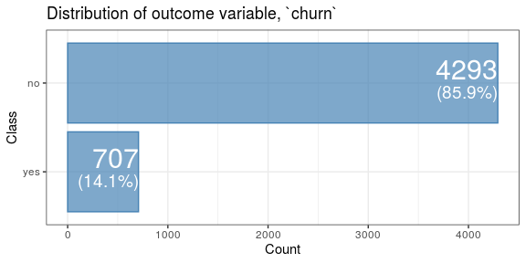

```r
df1 %>%
  count(churn) %>%
  mutate(prop = round(100*n/sum(n), 1)) %>%
  ggplot() +
  geom_col(aes(churn, n),
           fill = "steelblue", color = "steelblue", alpha = 0.7) +
  geom_text(aes(churn, n, label = n),
            hjust = 1, vjust = -0.2, size = 8,
            color = "white") +
  geom_text(aes(churn, n, label = paste0("(", prop, "%)")),
            hjust = 1, vjust = 1.2, size = 5,
            color = "white") +
  labs(x = "Class", y = "Count", title = "Distribution of outcome variable, `churn`") +
  coord_flip()
```

## Summary of all data

Summary of all data:

```r
bh_print_data_summary(df1)
```

```
                      [,1]
num_rows              "  5,000"
num_cols              "     20"
num_categorical_cols  "      5"
num_numeric_cols      "     15"
all_missing_cols      "      0"
complete_cols         "     20"
total_missing         "      0"
total_percent_missing "      0"
total_data_points     "100,000"
size_bytes            "569,288"
```

### Distributions

Histograms of all numerical variables:

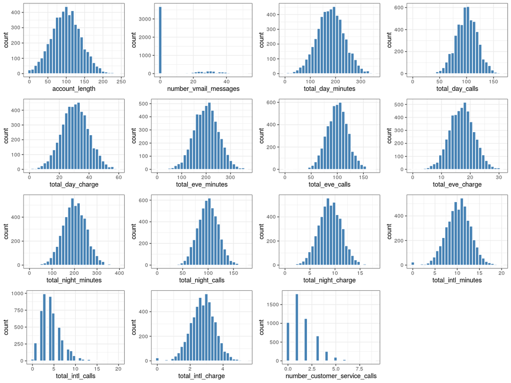

```r
bh_plot_histogram_grid(df1)
```

There are no degenerate distributions. Most of them look to approximately normally distributed. A couple are right-skewed. The distribution of `number_vmail_messages` seems to be bimodal, or even split up into two distributions. There is an inflation of zeros, and then a more normal-like distribution centered at about 30.

Bar plots of all categorical predictors:

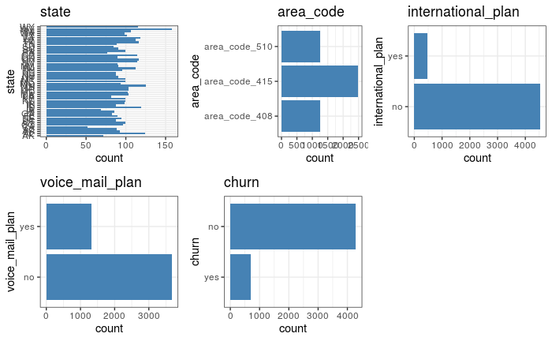

```r
bh_plot_bar_grid(df1, flip = TRUE)
```

### Outcome versus predictors

Plot box plots of the numerical predictors versus the outcome variable:

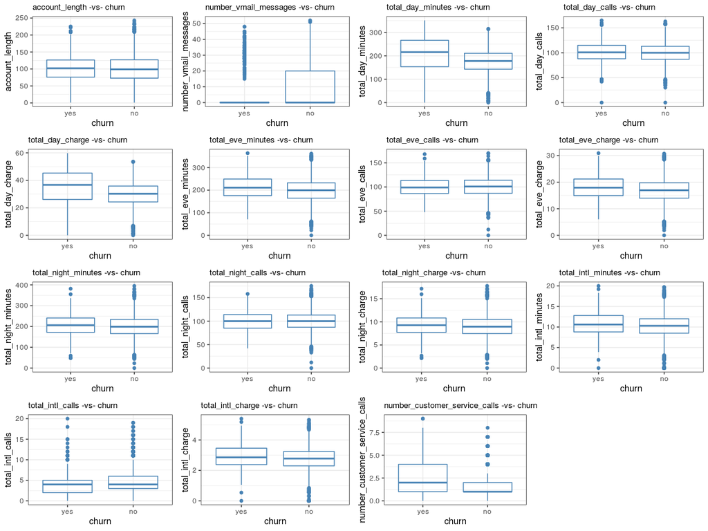

```r
bh_plot_boxplot_grid(df1, factor_var = "churn")
```

### Correlations

Plot the between-predictor correlations:

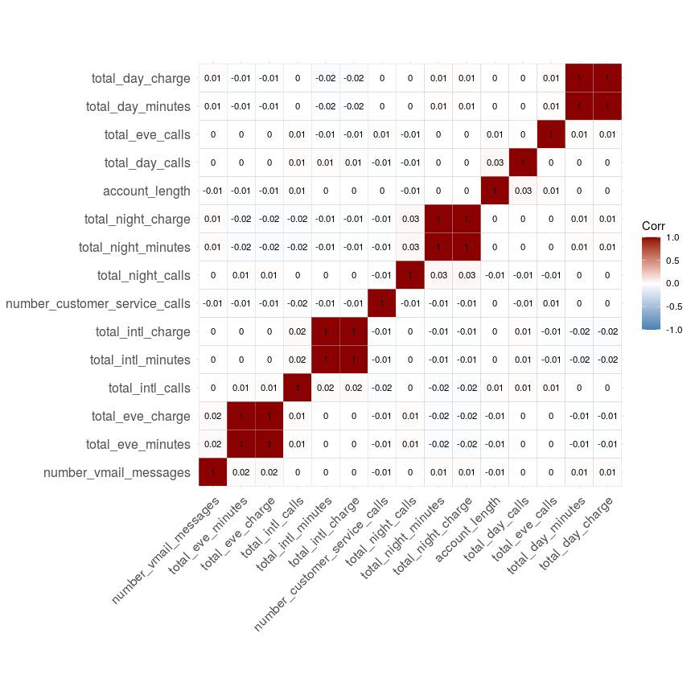

```r
correlations <- cor(df1[ , bh_numeric_cols(df1)])
ggcorrplot(correlations, hc.order = TRUE,
                 colors = c("steelblue", "white", "darkred"),
                 lab = TRUE, lab_size = 3, digits = 2)
```

The predictors are mostly uncorrelated with $r$ close to zero for most pairs. However, there are four predictor pairs with perfect correlation, $r = 1$:

- `total_day_minutes` and `total_day_charge`
- `total_night_minutes` and `total_night_charge`
- `total_eve_minutes` and `total_eve_charge`
- `total_intl_minutes` and `total_intl_charge`

These make sense considering that the `*charge` variables are likely calculated by multiplying the corresponding `*minute` variable by the appropriate fee per minute.

These will need to be filtered before modeling so that only one of each remains in the data. It can either be done manually by removing one of each correlated pair. It can also be done automatically using a recipe.

# (b)

Since this is a two class problem with imbalanced class distribution, I will use the accuracy rate and area under the ROC curve (AUC) to evaluate the models.

## Splitting and resampling data

Split the data into a training and test set. Also create resamples for use in cross-validation.

```r
# Rename outcome to `y`:
df1 <- mlc_churn
df1 <- dplyr::rename(df1, y = churn)

# Reverse the levels so that the "yes" is the second level:
df1 <- mutate(df1, y = factor(y, levels = c("no", "yes")))

set.seed(123)
#Training/test split:
splits1 <- initial_split(df1, strata = y) # default split is 75/25
df1_train <- training(splits1)
df1_test <- testing(splits1)

# 5-fold CV:
folds <- vfold_cv(df1_train, v = 5, strata = y)
```

## Preprocessing

This section investigates what type of preprocessing might be appropriate for the data.

There is one near-zero variance (NZV) predictor, `number_vmail_messages`. We already saw that this variable was potentially problematic due to the large number of zeros which distorted the distribution. We will remove this variable using a recipe.

```r
df1[, df1 %>% caret::nearZeroVar()] %>% names
```

```
[1] "number_vmail_messages"
```

Check to see if removing highly correlated predictors would remove any by using use `recipes::prep()`:

```r
df1_pp <-
  recipe(y ~ ., data = df1) %>%
  step_nzv(all_numeric()) %>%
  step_corr(all_numeric()) %>% # 0.9 is the default
  prep()

# This is a convoluted way of identifying what variables have been removed by filtering.
# The variables are numbered according to the step they were removed in, 0, 1 etc.
# If the variable is not filtered out then its `number` is equivalent to the largest number in the column.
# I am not sure of a better way to do this yet.
names(df1)[which(df1_pp$last_term_info$number != max(df1_pp$last_term_info$number))] # variables filtered out
```

```
[1] "voice_mail_plan"   "total_day_calls"   "total_eve_calls"   "total_night_calls" "total_intl_charge"
```

## Modeling

### Logistic Regression

For preprocessing, I will remove NZV variables and highly correlated variables. I will also center and scale the variables. No resampling is required for this model. I will just `fit()` a model on the training data and make predictions on the test data.

#### Training data

```r
# Preprocessing
rec1 <-
  recipe(y ~ ., data = df1_train) %>%
  step_center(all_numeric()) %>%
  step_scale(all_numeric()) %>%
  step_nzv(all_numeric()) %>%
  step_corr(all_numeric(), threshold = 0.9)

# Model
log_reg_mod1 <-
  logistic_reg() %>%
  set_mode("classification") %>%
  set_engine("glm")

# Workflow
workflow <-
  workflow() %>%
  add_model(spec = log_reg_mod1) %>%
  add_recipe(rec1)

# Fit
log_reg_fit <-
  workflow %>%
  fit(data = df1_train)

# View fit:
tidy(log_reg_fit)
```

| term | estimate | std.error | statistic | p.value |
| --- | --- | --- | --- | --- |
| (Intercept) | -2.798948 | 0.53536 | -5.22812 | 1.712e-07 |
| stateAL | 0.188920 | 0.64882 | 0.29118 | 7.709e-01 |
| stateAR | 0.580275 | 0.64638 | 0.89773 | 3.693e-01 |
| stateAZ | 0.407134 | 0.68846 | 0.59137 | 5.543e-01 |
| stateCA | 1.736942 | 0.69571 | 2.49663 | 1.254e-02 |
| stateCO | 0.230194 | 0.67710 | 0.33997 | 7.339e-01 |
| stateCT | 0.679578 | 0.63165 | 1.07588 | 2.820e-01 |
| stateDC | 0.525764 | 0.68216 | 0.77073 | 4.409e-01 |
| stateDE | 0.674989 | 0.62797 | 1.07487 | 2.824e-01 |
| stateFL | 0.623482 | 0.63699 | 0.97879 | 3.277e-01 |

[output cut: 55 more lines]

#### Testing data

```r
# Fit final model and make predictions:
final_fit <-
  workflow %>%
  last_fit(splits1)

# Collect predictions:
test_results <-
  final_fit %>%
  collect_predictions()
test_results$model <- "Logistic Regression"
```

### Linear Discriminant Analysis

For preprocessing, I will remove NZV variables and highly correlated variables. I will also center and scale the variables. No resampling is required for this model. I will just `fit()` a model on the training data and make predictions on the test data.

#### Training data

```r
# Preprocessing
rec1 <-
  recipe(y ~ ., data = df1_train) %>%
  step_center(all_numeric()) %>%
  step_scale(all_numeric()) %>%
  step_nzv(all_numeric()) %>%
  step_corr(all_numeric(), threshold = 0.9)

# Model
lda_mod1 <-
  discrim_linear() %>%
  set_mode("classification") %>%
  set_engine("MASS")

# Workflow
workflow <-
  workflow() %>%
  add_model(spec = lda_mod1) %>%
  add_recipe(rec1)

# Fit
lda_fit <-
  workflow %>%
  fit(data = df1_train)

# View fit:
#lda_fit
```

#### Testing data

```r
# Fit final model and make predictions:
final_fit <-
  workflow %>%
  last_fit(splits1)

# Collect predictions:
test_results <-
  rbind(
    test_results,
    cbind(
      final_fit %>%
        collect_predictions(),
      model = "LDA"
    )
  )
```

### Penalized Logistic Regression

**NOTE:** The `glmnet()` function requires a matrix of predictors. If the training data contains factors the various functions for creating a matrix from a data frame can be used if working in base `R`. With `tidymodels`, the recipe step `step_dummy()` can be used for this. Remember to include the correct selectors so that the response isn’t also converted.

For preprocessing, I will remove NZV variables and highly correlated variables. I will also center and scale the variables.

#### Training data

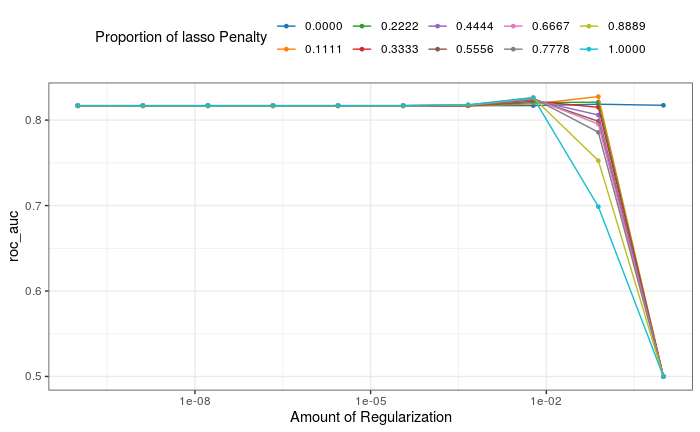

```r
# Preprocessing
rec1 <-
  recipe(y ~ ., data = df1_train) %>%
  step_center(all_numeric()) %>%
  step_scale(all_numeric()) %>%
  step_nzv(all_numeric()) %>%
  step_corr(all_numeric(), threshold = 0.9) %>%
  step_dummy(all_nominal(), -all_outcomes()) # convert all factors (nominal variables) but exclude `y`

# Model
penalized_log_reg_mod1 <-
  multinom_reg(mixture = tune(), penalty = tune()) %>%
  set_mode("classification") %>%
  set_engine("glmnet")

# Tuning grid:
grid1 <- grid_regular(penalty(), mixture(), levels = 10)

# Workflow
workflow <-
  workflow() %>%
  add_model(spec = penalized_log_reg_mod1) %>%
  add_recipe(rec1)

# Tune:
### Read in cached results if available:
file1 <- "/home/brian/R/dir/APM/chapter12/objects/penalized_log_reg_res1_12.3_.RDS"
if (file.exists(file1)) {
  penalized_log_reg_res1 <- readRDS(file1)
} else {
  penalized_log_reg_res1 <-
    workflow %>%
    tune_grid(resamples = folds, grid = grid1)
  saveRDS(penalized_log_reg_res1, file1)
}

# Plot AUC:
## Line plot:
autoplot(penalized_log_reg_res1, metric = "roc_auc") +
  ggsci::scale_color_d3() +
  theme(legend.position = "top")
```

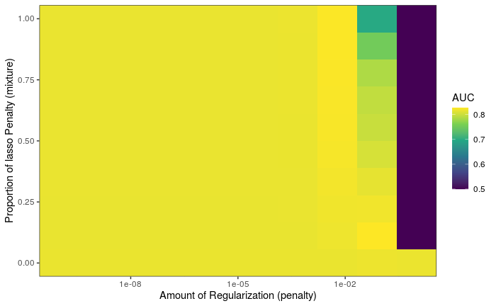

```r
## Tile plot like Fig. 12.16:
penalized_log_reg_res1 %>%
  collect_metrics() %>%
  filter(.metric == "roc_auc") %>%
  ggplot() +
  geom_tile(aes(penalty, mixture, fill = mean)) +
  scale_x_log10() +
  scale_fill_viridis_c() + # it looks better with the default direction
  coord_cartesian(expand = F) +
  labs(x = "Amount of Regularization (penalty)", y = "Proportion of lasso Penalty (mixture)", fill = "AUC")
```

#### Testing data

```r
# Select best model:
best_mod <- penalized_log_reg_res1 %>%
  select_best("roc_auc")

# Update final workflow:
final_wf <-
  workflow %>%
  finalize_workflow(best_mod)

# Fit final model and make predictions:
final_fit <-
  final_wf %>%
  last_fit(splits1)

# Collect predictions:
test_results <-
  rbind(
    test_results,
    cbind(
      final_fit %>%
        collect_predictions(),
      model = "Penalized Logistic Regression"
    )
  )
```

# (c)

## Metrics

### Calculate metrics

```r
# Return a combined set of metrics using the `caret` and `yardstick` packages:
get_metrics <- function(test_results, model) {
  test_results <- test_results %>%
    filter(model == {{ model }})

  metrics <- caret::confusionMatrix(data = test_results$.pred_class,
                                    reference = test_results$y,
                                    positive = "yes")

  metrics$auc <-
    test_results %>%
    yardstick::roc_auc(y, .pred_no) %>% # Need to put the first class in the test_results df here *1
    pluck(".estimate")

  return(metrics)
}

models <- unique(test_results$model)
metrics <- map(models, ~get_metrics(test_results, .x)) %>%
  set_names(models)
```

### Inspect metrics

#### AUC

Area under the ROC curve:

```r
map_dbl(metrics, ~.x$auc) %>% sort(decreasing = T)
```

```
Penalized Logistic Regression                           LDA           Logistic Regression
                       0.8388                        0.8348                        0.8220
```

#### Accuracy

```r
map_dbl(metrics, ~.x$overall[1]) %>% sort(decreasing = T)
```

```
Penalized Logistic Regression           Logistic Regression                           LDA
                       0.8623                        0.8607                        0.8583
```

The accuracy rates look good, but they are actually about the same as the null rate obtained by predicting the negative class for every observation:

```r
100*mean(df1_test$y == "no") # null rate
```

```
[1] 85.91
```

#### Sensitivity

```r
map_dbl(metrics, ~.x$byClass[1]) %>% sort(decreasing = T)
```

```
                          LDA           Logistic Regression Penalized Logistic Regression
                       0.2614                        0.2386                        0.0625
```

The sensitivity is low for these models. This means that even though the accuracy and AUC metrics seem reasonable, all of the models are poor at detecting instances of churn. **Chapter 16** covers methods for dealing with imbalanced outcomes like this.

#### Confusion matrices

Even though the models aren’t much better than the null model, they don’t actually predict the same class every time:

```r
map(metrics, ~.x$table)
```

```
$`Logistic Regression`
          Reference
Prediction   no  yes
       no  1033  134
       yes   40   42

$LDA
          Reference
Prediction   no  yes
       no  1026  130
       yes   47   46

$`Penalized Logistic Regression`
          Reference
Prediction   no  yes
       no  1066  165
       yes    7   11
```

### ROC Curves

Plot ROC curves:

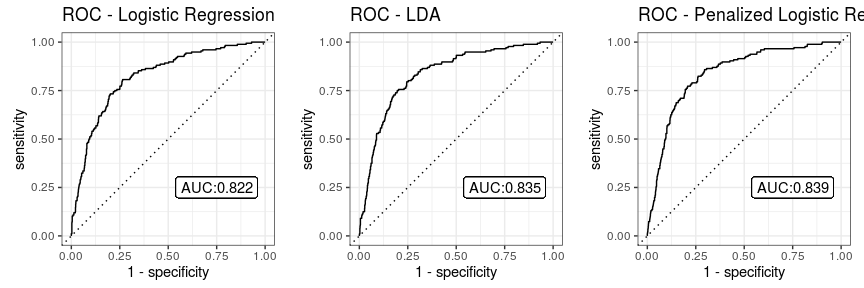

```r
# Returns an ROC curve for a given model.
# Includes a label indicating the AUC.
plot_roc_curve <- function(test_results, model) {

  # Get AUC for labeling the plot:
  auc <- metrics[[{{ model }}]]$auc

  # ROC curve:
  p <- test_results %>%
    filter(model == {{ model }}) %>%
    yardstick::roc_curve(y, .pred_yes, event_level = "second") %>%
    autoplot() +
    geom_label(aes(x = 0.75, y = 0.25, label = paste0("AUC:", round(auc, 3)))) +
    ggtitle(paste0("ROC - ", {{ model }}))
  return(p)
}

cowplot::plot_grid(
  plotlist = map(models, ~plot_roc_curve(test_results, .x)),
  nrow = 1
)
```

### Gain Curves

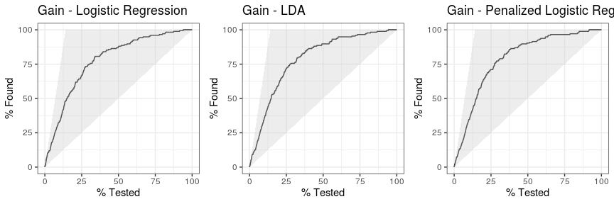

```r
# Returns a gain curve for a given model:
plot_gain_curve <- function(test_results, model) {

  # Gain curve:
  p <- test_results %>%
    filter(model == {{ model }}) %>%
    yardstick::gain_curve(y, .pred_yes, event_level = "second") %>%
    autoplot() +
    ggtitle(paste0("Gain - ", {{ model }}))
  return(p)
}

cowplot::plot_grid(
  plotlist = map(models, ~plot_gain_curve(test_results, .x)),
  nrow = 1
)
```

### Identify 80% of churning customers

For each model, find the specificity associated with a sensitivity of 80%:

```r
num_events <- sum(df1_test$y == "yes")
num_non_events <- sum(df1_test$y == "no")
test_results %>%
  group_by(model) %>%
  yardstick::roc_curve(y, .pred_yes, event_level = "second") %>%
  mutate(across(starts_with('s'), ~round(.x, 2))) %>%
  mutate(true_positives = round(sensitivity * num_events),
         false_positive_rate = 1 - specificity,
         false_positives = round((1 - specificity) * num_non_events)) %>%
  filter(sensitivity == 0.8) %>%
  slice_min(specificity) %>% # this includes ties
  dplyr::select(.threshold, sensitivity, true_positives, everything()) %>%
  slice_head(n = 1) # this gives us one for each group, even if there are ties
```

| .threshold | sensitivity | true_positives | model | specificity | false_positive_rate | false_positives |
| --- | --- | --- | --- | --- | --- | --- |
| 0.1046 | 0.8 | 141 | LDA | 0.73 | 0.27 | 290 |
| 0.1262 | 0.8 | 141 | Logistic Regression | 0.74 | 0.26 | 279 |
| 0.1437 | 0.8 | 141 | Penalized Logistic Regression | 0.74 | 0.26 | 279 |

For the LDA model, the specificity associated with a sensitivity of 80% is 73%. This gives us a false positive rate of 100 - 73 = 27%. So if we want to identify 80% of churning customers, 27% of the non-churning customers are also identified by the LDA model. This means that we would identify about 141 true positives (80% of 176) and about 290 false positives (27% of 1073):

Note that the probability thresholds for a sensitivity of `0.8` are much lower than the default of 50%. This is covered in greater detail in **Chapter 16**.

[^1]: Kuhn M, Johnson K (2013). *Applied Predictive Modeling*. Springer.
[^2]: http://www.sgi.com/tech/mlc